# Assignment_NLP_2_Nov2020

[figure not shown]

Proprietary content. © Great Learning. All Rights Reserved. Unauthorized use or distribution prohibited.

### Package Version:

- tensorflow==2.2.0
- pandas==1.0.5
- numpy==1.18.5
- google==2.0.3

# Sarcasm Detection

### Dataset

#### Acknowledgement

Misra, Rishabh, and Prahal Arora. "Sarcasm Detection using Hybrid Neural Network." arXiv preprint arXiv:1908.07414 (2019).

**Required Files given in below link.**

https://drive.google.com/drive/folders/1xUnF35naPGU63xwRDVGc-DkZ3M8V5mMk

### Load Data (5 Marks)

```python
from google.colab import drive
drive.mount('/content/drive')
```

```python
import pandas as pd
import numpy as np

datasetPath = '/content/drive/My Drive/GL/Dataset/Sarcasm Detection/Data/'
df = pd.read_json(datasetPath + 'Sarcasm_Headlines_Dataset.json', lines=True)
print(df.shape)
df.head(10)
```

```
(26709, 3)
```

|  | article_link | headline | is_sarcastic |
| --- | --- | --- | --- |
| 0 | https://www.huffingtonpost.com/entry/versace-b... | former versace store clerk sues over secret 'b... | 0 |
| 1 | https://www.huffingtonpost.com/entry/roseanne-... | the 'roseanne' revival catches up to our thorn... | 0 |
| 2 | https://local.theonion.com/mom-starting-to-fea... | mom starting to fear son's web series closest ... | 1 |
| 3 | https://politics.theonion.com/boehner-just-wan... | boehner just wants wife to listen, not come up... | 1 |
| 4 | https://www.huffingtonpost.com/entry/jk-rowlin... | j.k. rowling wishes snape happy birthday in th... | 0 |
| 5 | https://www.huffingtonpost.com/entry/advancing... | advancing the world's women | 0 |
| 6 | https://www.huffingtonpost.com/entry/how-meat-... | the fascinating case for eating lab-grown meat | 0 |
| 7 | https://www.huffingtonpost.com/entry/boxed-col... | this ceo will send your kids to school, if you... | 0 |
| 8 | https://politics.theonion.com/top-snake-handle... | top snake handler leaves sinking huckabee camp... | 1 |
| 9 | https://www.huffingtonpost.com/entry/fridays-m... | friday's morning email: inside trump's presser... | 0 |

### Drop `article_link` from dataset (5 Marks)

```python
data=df[["headline","is_sarcastic"]]
data.head(10)
```

|  | headline | is_sarcastic |
| --- | --- | --- |
| 0 | former versace store clerk sues over secret 'b... | 0 |
| 1 | the 'roseanne' revival catches up to our thorn... | 0 |
| 2 | mom starting to fear son's web series closest ... | 1 |
| 3 | boehner just wants wife to listen, not come up... | 1 |
| 4 | j.k. rowling wishes snape happy birthday in th... | 0 |
| 5 | advancing the world's women | 0 |
| 6 | the fascinating case for eating lab-grown meat | 0 |
| 7 | this ceo will send your kids to school, if you... | 0 |
| 8 | top snake handler leaves sinking huckabee camp... | 1 |
| 9 | friday's morning email: inside trump's presser... | 0 |

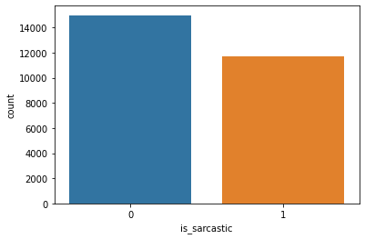

```python
import seaborn as sns
sns.countplot(data.is_sarcastic)
```

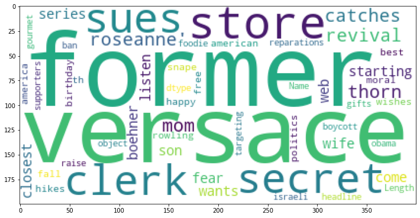

```python
from wordcloud import WordCloud, STOPWORDS
import matplotlib.pyplot as plt

wordcloud = WordCloud(background_color='white',
                    stopwords = STOPWORDS,
                    random_state = 101)
wordcloud.generate(str(data['headline']))
plt.figure(figsize = (12,10))
plt.imshow(wordcloud)
```

### Get length of each headline and add a column for that (5 Marks)

```python
data['headline_length']  = data['headline'].str.len()
```

```python
data.head(10)
```

|  | headline | is_sarcastic | headline_length |
| --- | --- | --- | --- |
| 0 | former versace store clerk sues over secret 'b... | 0 | 78 |
| 1 | the 'roseanne' revival catches up to our thorn... | 0 | 84 |
| 2 | mom starting to fear son's web series closest ... | 1 | 79 |
| 3 | boehner just wants wife to listen, not come up... | 1 | 84 |
| 4 | j.k. rowling wishes snape happy birthday in th... | 0 | 64 |
| 5 | advancing the world's women | 0 | 27 |
| 6 | the fascinating case for eating lab-grown meat | 0 | 46 |
| 7 | this ceo will send your kids to school, if you... | 0 | 67 |
| 8 | top snake handler leaves sinking huckabee camp... | 1 | 50 |
| 9 | friday's morning email: inside trump's presser... | 0 | 59 |

### Initialize parameter values

- Set values for max_features, maxlen, & embedding_size
- max_features: Number of words to take from tokenizer(most frequent words)
- maxlen: Maximum length of each sentence to be limited to 25
- embedding_size: size of embedding vector

```python
max_features = 10000
maxlen = 25
embedding_size = 200
```

### Apply `tensorflow.keras` Tokenizer and get indices for words (5 Marks)

- Initialize Tokenizer object with number of words as 10000
- Fit the tokenizer object on headline column
- Convert the text to sequence

```python
import re
from tensorflow.keras.preprocessing.text import Tokenizer
data['headline'] = data['headline'].apply(lambda x: x.lower())
data['headline'] = data['headline'].apply((lambda x: re.sub('[^a-zA-z0-9\s]','',x)))

tokenizer = Tokenizer(num_words=max_features, split=' ', oov_token='<UNK>')
tokenizer.fit_on_texts(data['headline'].values)
sequences = tokenizer.texts_to_sequences(data['headline'].values)
```

### Pad sequences (5 Marks)

- Pad each example with a maximum length
- Convert target column into numpy array

```python
from tensorflow.keras.preprocessing.sequence import pad_sequences

X = pad_sequences(sequences, padding="post", maxlen=maxlen)
targets = data['is_sarcastic'].to_numpy()
print(targets.shape)
```

```
(26709,)
```

```python
idx = 41
print(data['headline'][idx])
print(sequences[idx])
print(X[idx])
print(X.shape)
```

```
scott used to stop breathing nearly 40 times an hour this device changed his life
[632, 361, 2, 183, 3290, 1099, 1245, 379, 63, 952, 19, 3557, 1464, 33, 69]
[ 632  361    2  183 3290 1099 1245  379   63  952   19 3557 1464   33
   69    0    0    0    0    0    0    0    0    0    0]
(26709, 25)
```

### Vocab mapping

- There is no word for 0th index

```python
tokenizer.word_index
```

```
{'<UNK>': 1,
 'to': 2,
 'of': 3,
 'the': 4,
 'in': 5,
 'for': 6,
 'a': 7,
 'on': 8,
 'and': 9,
 'with': 10,
 'is': 11,
 'new': 12,
 'trump': 13,
 'man': 14,
 'from': 15,
 'at': 16,
 'about': 17,
 'you': 18,
 'this': 19,
 'by': 20,
 'after': 21,
 'be': 22,
 'how': 23,
 'out': 24,
 'it': 25,
 'that': 26,
 'as': 27,
 'up': 28,
 'not': 29,
 'are': 30,
 'your': 31,
 'what': 32,
 'his': 33,
 'he': 34,
 'just': 35,
 'who': 36,
 'us': 37,
 'has': 38,
 'will': 39,
 'more': 40,
```

[output cut: 946 more lines]

```
 'apparently': 987,
 'dads': 988,
 'went': 989,
 'chicken': 990,
 'dogs': 991,
 'opening': 992,
 'mean': 993,
 'said': 994,
 'apologizes': 995,
 'teachers': 996,
 'culture': 997,
 'elizabeth': 998,
 'ebola': 999,
 'responds': 1000,
 ...}
```

### Set number of words

- Since the above 0th index doesn't have a word, add 1 to the length of the vocabulary

```python
num_words = len(tokenizer.word_index) + 1
print(num_words)
```

```
28400
```

Train & Test Data Split

```python
from sklearn.model_selection import train_test_split
Xtrain, Xtest, ytrain, ytest = train_test_split(X, targets, test_size=0.2)
Xtrain, Xval, ytrain, yval = train_test_split(Xtrain, ytrain, test_size=0.2)

print(Xtrain.shape)
print(Xtest.shape)
print(Xval.shape)
print(ytrain.shape)
print(ytest.shape)
print(yval.shape)
```

```
(17093, 25)
(5342, 25)
(4274, 25)
(17093,)
(5342,)
(4274,)
```

### Load Glove Word Embeddings (5 Marks)

```python
EMBEDDING_FILE = datasetPath + 'glove.6B.200d.txt'

embeddings = {}
for o in open(EMBEDDING_FILE):
    word = o.split(" ")[0]
    # print(word)
    embd = o.split(" ")[1:]
    embd = np.asarray(embd, dtype='float32')
    # print(embd)
    embeddings[word] = embd
```

### Create embedding matrix

```python
# create a weight matrix for words in training docs
embedding_matrix = np.zeros((num_words, embedding_size))

for word, i in tokenizer.word_index.items():
	embedding_vector = embeddings.get(word)
	if embedding_vector is not None:
		embedding_matrix[i] = embedding_vector
```

### Define model (10 Marks)

- Hint: Use Sequential model instance and then add Embedding layer, Bidirectional(LSTM) layer, flatten it, then dense and dropout layers as required. In the end add a final dense layer with sigmoid activation for binary classification.

```python
import tensorflow as tf

model = tf.keras.Sequential([
    tf.keras.layers.Embedding(num_words, embedding_size, input_length=maxlen,weights=[embedding_matrix], trainable=False),
    tf.keras.layers.Bidirectional(tf.keras.layers.LSTM(64,return_sequences=True)),
    tf.keras.layers.Bidirectional(tf.keras.layers.LSTM(32)),
    tf.keras.layers.Flatten(),
    tf.keras.layers.Dense(16, activation='relu'),
    tf.keras.layers.Dropout(0.5),
    tf.keras.layers.Dense(1, activation='sigmoid')
])
model.summary()
```

```
Model: "sequential"
_________________________________________________________________
Layer (type)                 Output Shape              Param #
=================================================================
embedding (Embedding)        (None, 25, 200)           5680000
_________________________________________________________________
bidirectional (Bidirectional (None, 25, 128)           135680
_________________________________________________________________
bidirectional_1 (Bidirection (None, 64)                41216
_________________________________________________________________
flatten (Flatten)            (None, 64)                0
_________________________________________________________________
dense (Dense)                (None, 16)                1040
_________________________________________________________________
dropout (Dropout)            (None, 16)                0
_________________________________________________________________
dense_1 (Dense)              (None, 1)                 17
=================================================================
Total params: 5,857,953
Trainable params: 177,953
Non-trainable params: 5,680,000
_________________________________________________________________
```

### Compile the model (5 Marks)

```python
model.compile(loss='binary_crossentropy', optimizer='adam', metrics=['accuracy'])
```

### Fit the model (5 Marks)

```python
def PlotTrainingResults(data):
  plt.figure(figsize=(15,5))

  # summarize history for accuracy
  plt.subplot(1, 2, 1)
  plt.plot(data['accuracy'])
  plt.plot(data['val_accuracy'])
  plt.title('Model Accuracy')
  plt.ylabel('accuracy')
  plt.xlabel('epoch')
  plt.legend(['train', 'validation'], loc='upper left')

  # summarize history for loss
  plt.subplot(1, 2, 2)
  plt.plot(data['loss'])
  plt.plot(data['val_loss'])
  plt.title('Model Loss')
  plt.ylabel('loss')
  plt.xlabel('epoch')
  plt.legend(['train', 'validation'], loc='upper right')
  plt.show()
```

```python
history = model.fit(Xtrain, ytrain, epochs=10, batch_size=32, verbose=1, validation_data=(Xval, yval))
```

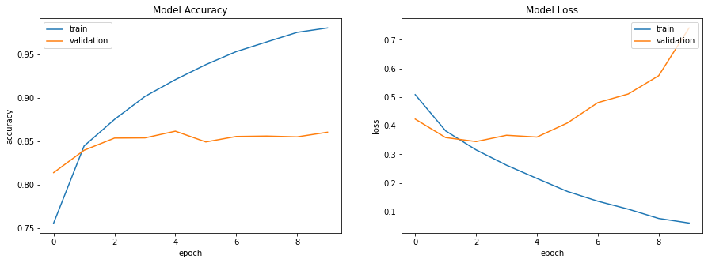

```python
PlotTrainingResults(history.history)
```

```python
score = model.evaluate(Xtest, ytest)
print('Test Loss: ', score[0])
print('Test Accuracy: ', score[1])
```

```
Test Loss:  0.7046055197715759
Test Accuracy:  0.8607262969017029
```